```python
from __future__ import annotations

import matplotlib.pyplot as plt
import numpy as np
import pandas as pd

from mxlpy import (
    OdeModelBuilder,
    Simulator,
    cartesian_product,
    OdeRunner,
    fit,
    make_protocol,
    mca,
    plot,
    scan,
)
from mxlpy.meta import generate_model_code_mxlweb
```

from __future__ import annotations import matplotlib.pyplot as plt import numpy as np import pandas as pd from mxlpy import ( OdeModelBuilder, Simulator, cartesian_product, OdeRunner, fit, make_protocol, mca, plot, scan, ) from mxlpy.meta import generate_model_code_mxlweb

# ODE models

*mxlpy* has three model builders, which differ in how the right hand side of the system is written down:

| Builder | Right hand side | Typical use |
| --- | --- | --- |
| `KineticModelBuilder` (`Model`) | \(N \cdot v(x)\): reactions with rate laws and a stoichiometric matrix | metabolic & signalling networks |
| `OdeModelBuilder` | \(\frac{dx}{dt} = f(x)\): one differential equation per variable | phenomenological models, equations taken from a paper |
| `SteadyStateModelBuilder` | no variables, only explicit functions of parameters | algebraic / steady-state models, see Steady-state models |

This notebook covers the `OdeModelBuilder`. Use it when your model is naturally written as differential equations rather than as a reaction network. Since there are no reactions, an `OdeModelBuilder` has no fluxes and no stoichiometries.

As an example we use logistic growth with a constant harvesting rate \(h\)

\[\frac{dx}{dt} = r x \left(1 - \frac{x}{K}\right) - h x\]

which has the non-trivial steady state \(x^* = K \left(1 - \frac{h}{r}\right)\).

## Building the model

Instead of `add_reaction`, every variable gets exactly one differential equation via `add_diff_eq`, which also sets the variable's initial value. Parameters and derived quantities work just like in the `KineticModelBuilder`.

As with all builders, use named functions instead of lambdas (they need to be inspectable and pickle-able).

```python
def logistic_harvest(x: float, r: float, capacity: float, h: float) -> float:
    return r * x * (1 - x / capacity) - h * x


def fraction(x: float, capacity: float) -> float:
    return x / capacity


def get_model() -> OdeModelBuilder:
    return (
        OdeModelBuilder()
        .add_parameters({"r": 1.0, "capacity": 10.0, "h": 0.2})
        .add_diff_eq(
            "x",
            fn=logistic_harvest,
            args=["x", "r", "capacity", "h"],
            initial_value=0.5,
        )
        .add_derived("saturation", fn=fraction, args=["x", "capacity"])
    )


model = get_model()
model.diff_eqs
```

def logistic_harvest(x: float, r: float, capacity: float, h: float) -> float: return r * x * (1 - x / capacity) - h * x def fraction(x: float, capacity: float) -> float: return x / capacity def get_model() -> OdeModelBuilder: return ( OdeModelBuilder() .add_parameters({"r": 1.0, "capacity": 10.0, "h": 0.2}) .add_diff_eq( "x", fn=logistic_harvest, args=["x", "r", "capacity", "h"], initial_value=0.5, ) .add_derived("saturation", fn=fraction, args=["x", "capacity"]) ) model = get_model() model.diff_eqs

|  | value | initial | unit |
| --- | --- | --- | --- |
| x | \(- h x + r x \left(1.0 - \frac{x}{capacity}\right)\) | 0.5 |  |

```python
model.derived
```

model.derived

|  | value | unit |
| --- | --- | --- |
| saturation | \(\frac{x}{capacity}\) |  |

The right hand side can be evaluated directly, either at the initial conditions or at custom values

```python
model.get_right_hand_side({"x": 5.0})
```

model.get_right_hand_side({"x": 5.0})

```
x    1.5
dtype: float64
```

Initial values can be changed with `update_variable` / `update_variables`

```python
get_model().update_variable("x", 2.0).get_initial_conditions()
```

get_model().update_variable("x", 2.0).get_initial_conditions()

```
{'x': 2.0}
```

## Simulation

An `OdeModelBuilder` is simulated with the same `Simulator` as a `KineticModelBuilder`. The result is an `OdeSimulation`, which offers the same access patterns as a `Simulation`, minus everything flux related.

Routines like scans and fits configure the simulation with an `OdeRunner` instead, see the integrator configuration.

```python
res = Simulator(get_model()).simulate(t_end=15).get_result().unwrap_or_err()

fig, (ax1, ax2) = plot.two_axes(figsize=(7, 3))
plot.lines(res.variables, ax=ax1)
plot.lines(res.get_right_hand_side(), ax=ax2)
ax1.set(xlabel="time / a.u.", ylabel="value / a.u.")
ax2.set(xlabel="time / a.u.", ylabel="dx/dt / a.u.")
plt.show()
```

res = Simulator(get_model()).simulate(t_end=15).get_result().unwrap_or_err() fig, (ax1, ax2) = plot.two_axes(figsize=(7, 3)) plot.lines(res.variables, ax=ax1) plot.lines(res.get_right_hand_side(), ax=ax2) ax1.set(xlabel="time / a.u.", ylabel="value / a.u.") ax2.set(xlabel="time / a.u.", ylabel="dx/dt / a.u.") plt.show()

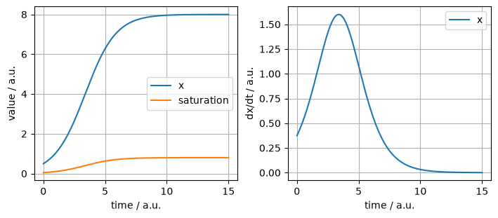

`get_combined` returns all variables, derived variables and readouts as a single `pandas.DataFrame`. `get_args` additionally allows including parameters and derived parameters.

```python
res.get_args(include_parameters=True).tail()
```

res.get_args(include_parameters=True).tail()

|  | x | r | capacity | h | saturation |
| --- | --- | --- | --- | --- | --- |
| 14.141277 | 7.998535 | 1.0 | 10.0 | 0.2 | 0.799853 |
| 14.372871 | 7.998782 | 1.0 | 10.0 | 0.2 | 0.799878 |
| 14.604465 | 7.998988 | 1.0 | 10.0 | 0.2 | 0.799899 |
| 14.836058 | 7.999159 | 1.0 | 10.0 | 0.2 | 0.799916 |
| 15.000000 | 7.999263 | 1.0 | 10.0 | 0.2 | 0.799926 |

Steady states and protocols work as usual. For the default parameters the steady state is at \(x^* = 10 \cdot (1 - 0.2) = 8\)

```python
Simulator(get_model()).simulate_to_steady_state().get_result().unwrap_or_err().get_new_y0()
```

Simulator(get_model()).simulate_to_steady_state().get_result().unwrap_or_err().get_new_y0()

```
{'x': np.float64(8.0)}
```

```python
protocol = make_protocol(
    [
        (10, {"h": 0.2}),
        (10, {"h": 0.6}),  # overharvesting
        (10, {"h": 0.2}),
    ]
)
res = (
    Simulator(get_model())
    .simulate_protocol(protocol, time_points_per_step=20)
    .get_result()
    .unwrap_or_err()
)

fig, ax = plot.lines(res.get_variables(include_derived_variables=False))
plot.shade_protocol(protocol["h"], ax=ax, alpha=0.1)
ax.set(xlabel="time / a.u.", ylabel="x / a.u.")
plt.show()
```

protocol = make_protocol( [ (10, {"h": 0.2}), (10, {"h": 0.6}), # overharvesting (10, {"h": 0.2}), ] ) res = ( Simulator(get_model()) .simulate_protocol(protocol, time_points_per_step=20) .get_result() .unwrap_or_err() ) fig, ax = plot.lines(res.get_variables(include_derived_variables=False)) plot.shade_protocol(protocol["h"], ax=ax, alpha=0.1) ax.set(xlabel="time / a.u.", ylabel="x / a.u.") plt.show()

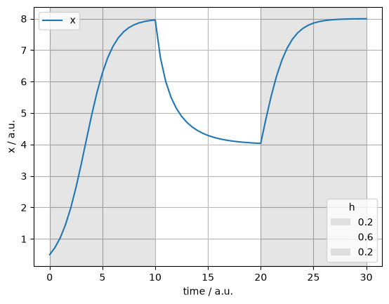

## Parameter scans

All functions of the `scan` module accept an `OdeModelBuilder`. Their results have the same shape as for a `KineticModelBuilder`, just without fluxes. The same goes for the Monte Carlo routines in `mc`.

cache

```python
res = scan.steady_state(
    get_model(),
    to_scan=pd.DataFrame({"h": np.linspace(0, 0.9, 10)}),
    runner=OdeRunner(tolerance=1e-8),
)

fig, ax = plot.lines(res.variables)
ax.set(xlabel="harvesting rate h / a.u.", ylabel="steady state / a.u.")
plt.show()
```

res = scan.steady_state( get_model(), to_scan=pd.DataFrame({"h": np.linspace(0, 0.9, 10)}), runner=OdeRunner(tolerance=1e-8), ) fig, ax = plot.lines(res.variables) ax.set(xlabel="harvesting rate h / a.u.", ylabel="steady state / a.u.") plt.show()

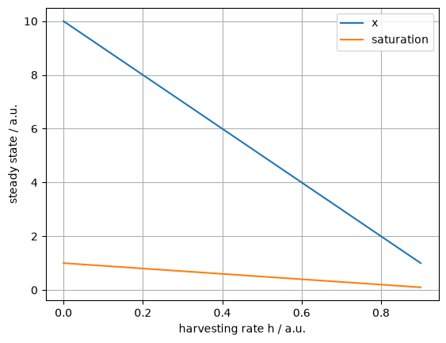

Scanning multiple parameters works via `cartesian_product`

cache

```python
res = scan.steady_state(
    get_model(),
    to_scan=cartesian_product(
        {
            "h": np.linspace(0, 0.9, 10),
            "capacity": np.linspace(5, 15, 5),
        }
    ),
)

fig, ax, _ = plot.heatmap_from_2d_idx(res.variables, "x")
ax.set(xlabel="h", ylabel="capacity", title="steady state of x")
plt.show()
```

res = scan.steady_state( get_model(), to_scan=cartesian_product( { "h": np.linspace(0, 0.9, 10), "capacity": np.linspace(5, 15, 5), } ), ) fig, ax, _ = plot.heatmap_from_2d_idx(res.variables, "x") ax.set(xlabel="h", ylabel="capacity", title="steady state of x") plt.show()

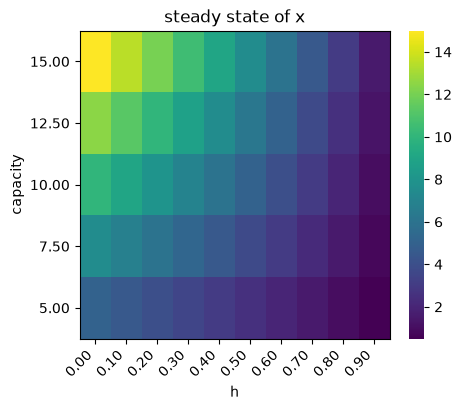

The `to_scan` DataFrame can also contain initial conditions

cache

```python
res = scan.time_course(
    get_model(),
    to_scan=pd.DataFrame({"x": [0.1, 1.0, 5.0, 15.0]}),
    time_points=np.linspace(0, 10, 101),
)

fig, ax = plot.lines(res.get_by_name("x"))
ax.set(xlabel="time / a.u.", ylabel="x / a.u.")
plt.show()
```

res = scan.time_course( get_model(), to_scan=pd.DataFrame({"x": [0.1, 1.0, 5.0, 15.0]}), time_points=np.linspace(0, 10, 101), ) fig, ax = plot.lines(res.get_by_name("x")) ax.set(xlabel="time / a.u.", ylabel="x / a.u.") plt.show()

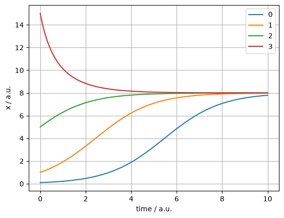

## Fitting

All fitting routines except the reaction carousel accept an `OdeModelBuilder`. The returned `Fit` contains a copy of the `OdeModelBuilder`.

Here we create some synthetic data with known parameters and fit the model to it.

```python
data = (
    Simulator(get_model().update_parameters({"r": 0.7, "h": 0.35}))
    .simulate_time_course(np.linspace(0, 15, 31))
    .get_result()
    .unwrap_or_err()
    .get_variables(
        include_derived_variables=False,
        include_readouts=False,
        include_surrogate_variables=False,
    )
)

fitted = fit.time_course(
    get_model(),
    p0={"r": 1.0, "h": 0.2},
    data=data,
    minimizer=fit.LocalScipyMinimizer(),
).unwrap_or_err()
fitted.best_pars
```

data = ( Simulator(get_model().update_parameters({"r": 0.7, "h": 0.35})) .simulate_time_course(np.linspace(0, 15, 31)) .get_result() .unwrap_or_err() .get_variables( include_derived_variables=False, include_readouts=False, include_surrogate_variables=False, ) ) fitted = fit.time_course( get_model(), p0={"r": 1.0, "h": 0.2}, data=data, minimizer=fit.LocalScipyMinimizer(), ).unwrap_or_err() fitted.best_pars

```
{'r': np.float64(0.6999994776847334), 'h': np.float64(0.3499996635736488)}
```

```python
res = (
    Simulator(fitted.model.update_parameters(fitted.best_pars))
    .simulate_time_course(data.index)
    .get_result()
    .unwrap_or_err()
)

fig, ax = plot.lines(res.get_variables(include_derived_variables=False))
ax.scatter(data.index, data["x"], color="black", label="data")
ax.set(xlabel="time / a.u.", ylabel="x / a.u.")
ax.legend()
plt.show()
```

res = ( Simulator(fitted.model.update_parameters(fitted.best_pars)) .simulate_time_course(data.index) .get_result() .unwrap_or_err() ) fig, ax = plot.lines(res.get_variables(include_derived_variables=False)) ax.scatter(data.index, data["x"], color="black", label="data") ax.set(xlabel="time / a.u.", ylabel="x / a.u.") ax.legend() plt.show()

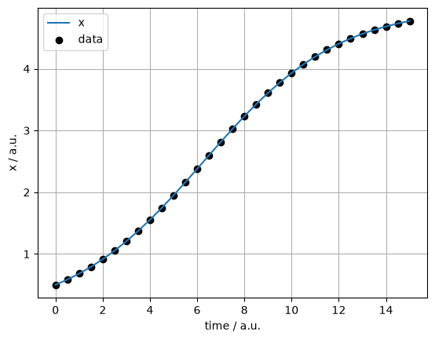

## Response coefficients

Response coefficients describe how much the steady state changes if a parameter is perturbed. For an `OdeModelBuilder` they are available for the variables. With the default normalisation, the steady state \(x^* = K (1 - h / r)\) responds proportionally to the carrying capacity \(K\).

```python
mca.response_coefficients(get_model()).variables
```

mca.response_coefficients(get_model()).variables

|  | r | capacity | h |
| --- | --- | --- | --- |
| x | 0.25 | 1.000000e+00 | -0.25 |
| saturation | 0.25 | 1.734723e-16 | -0.25 |

## Export

`OdeModelBuilder` models can be saved to the native `.mxl.json` format with `mxlpy.save` / `mxlpy.load`, and exported to [MxlWeb](https://github.com/Computational-Biology-Aachen/mxl-web), which natively supports differential equation models.

```python
print(generate_model_code_mxlweb(get_model()))
```

print(generate_model_code_mxlweb(get_model()))

```
import { OdeModelBuilder } from "@computational-biology-aachen/mxlweb-core";
import { Add, Divide, Minus, Mul, Name, Num } from "@computational-biology-aachen/mxlweb-core/mathml";

export function initModel(): OdeModelBuilder {
    return new OdeModelBuilder()
      .addParameter("r", {
        value: 1.0,
        texName: 'r',
      })
      .addParameter("capacity", {
        value: 10.0,
        texName: 'capacity',
      })
      .addParameter("h", {
        value: 0.2,
        texName: 'h',
      })
      .addVariable("x", {
        value: 0.5,
        texName: 'x',
      })
      .addAssignment("saturation", {
        fn: new Divide([new Name("x"), new Name("capacity")]),
        texName: 'saturation',
      })
      .setDifferential("x", new Add([new Minus([new Mul([new Name("h"), new Name("x")])]), new Mul([new Name("r"), new Name("x"), new Add([new Num(1.0), new Minus([new Divide([new Name("x"), new Name("capacity")])])])])]))
  }
```

## Current limitations

Everything about reactions, fluxes or stoichiometries only applies to the `KineticModelBuilder`. Not supported for the `OdeModelBuilder` are thus

- flux elasticities and rate characteristics in `mca`, reaction carousels, model comparisons and label models
- Jacobians (`Simulator(..., use_jacobian=True)` falls back to finite differences with a warning) and events